# Reproductible Reseach: Peer Assessment 1

Ric

Saturday, August 16, 2014

## Introduction

This is the first peer assessment for the Reproducible Research course from John Hopkins University, via coursera. This assignment combines the tools of R programming, data analysis, knitr, git, gitHub, and other tools learned through the first five courses in this Data Science certificate program.

All the R code and results will be displayed.

Each section in this assignment will be defined by a heading.

## Loading and preprocessing the data

For this first section, we are to show how the raw code was imported into R for analysis and the steps proformed.

The assumption is the raw csv file is in the working directory.

```r
setwd("C:/Users/ric/RepData_PA1")
getwd() ## check working directory has been set.
```

```
## [1] "C:/Users/ric/RepData_PA1"
```

```r
activityDataRaw <- read.csv("activity.csv")  ## read data into R dataframe.
```

==============================  
Begin data file inspection  
==============================

```r
str(activityDataRaw) ## inspect structure of data
```

```
## 'data.frame':    17568 obs. of  3 variables:
##  $ steps   : int  NA NA NA NA NA NA NA NA NA NA ...
##  $ date    : Factor w/ 61 levels "2012-10-01","2012-10-02",..: 1 1 1 1 1 1 1 1 1 1 ...
##  $ interval: int  0 5 10 15 20 25 30 35 40 45 ...
```

```r
summary(activityDataRaw)
```

```
##      steps               date          interval
##  Min.   :  0.0   2012-10-01:  288   Min.   :   0
##  1st Qu.:  0.0   2012-10-02:  288   1st Qu.: 589
##  Median :  0.0   2012-10-03:  288   Median :1178
##  Mean   : 37.4   2012-10-04:  288   Mean   :1178
##  3rd Qu.: 12.0   2012-10-05:  288   3rd Qu.:1766
##  Max.   :806.0   2012-10-06:  288   Max.   :2355
##  NA's   :2304    (Other)   :15840
```

```r
head(activityDataRaw)  ## display first few rows of data
```

```
##   steps       date interval
## 1    NA 2012-10-01        0
## 2    NA 2012-10-01        5
## 3    NA 2012-10-01       10
## 4    NA 2012-10-01       15
## 5    NA 2012-10-01       20
## 6    NA 2012-10-01       25
```

```r
tail(activityDataRaw)  ## display last rows of data
```

```
##       steps       date interval
## 17563    NA 2012-11-30     2330
## 17564    NA 2012-11-30     2335
## 17565    NA 2012-11-30     2340
## 17566    NA 2012-11-30     2345
## 17567    NA 2012-11-30     2350
## 17568    NA 2012-11-30     2355
```

```r
sum(is.na(activityDataRaw$steps)) #  determine number of NA values (which is also seen in the summary)
```

```
## [1] 2304
```

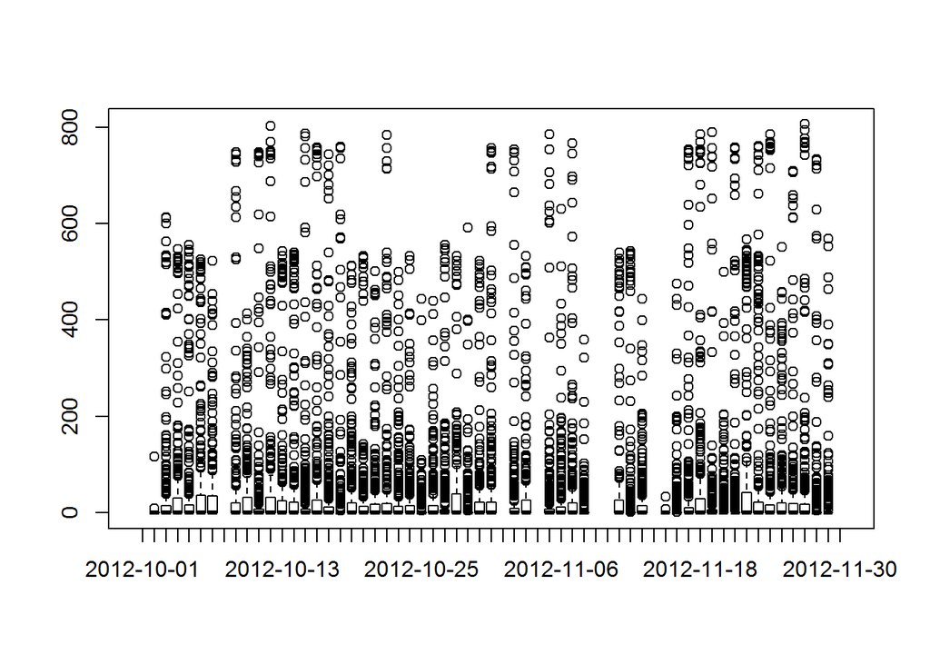

```r
plot(activityDataRaw$date, activityDataRaw$steps)  ## quick look at two variables
```

This completes the preprocessing section of this assignment.

## What is the mean total number of steps taken per day?

In this section of the assignment, the missing values (NA) observations are removed from the dataset.

```r
activityData <- subset(na.omit(activityDataRaw))  ## build new dataset without NA values.
head(activityData)  ## check first few rows.
```

```
##     steps       date interval
## 289     0 2012-10-02        0
## 290     0 2012-10-02        5
## 291     0 2012-10-02       10
## 292     0 2012-10-02       15
## 293     0 2012-10-02       20
## 294     0 2012-10-02       25
```

Earlier, it was determined that there were 2304 NA observations in the original dataset of 17,568 observations. Therefore, an arithmetic calculation shows that 13 percent of the original dataset has been removed.

```r
2304/17568*100
```

```
## [1] 13.11
```

===================================================================  
Will now build a historgram of the total number of steps taken each day.  
===================================================================  
Calculate the total steps taken per day:

```r
totalSteps <- tapply(activityData$steps, activityData$date, sum)  ## find the total steps count.
head(totalSteps)  ## show some of the data
```

```
## 2012-10-01 2012-10-02 2012-10-03 2012-10-04 2012-10-05 2012-10-06
##         NA        126      11352      12116      13294      15420
```

NA values have reappeared; therefore, the data will be sorted to move the NA values to the bottom and then removed:

```r
totalStepsSorted <- sort(totalSteps, na.last=TRUE)  ## sort and move NA values to last
totalStepsData <- totalStepsSorted[c(1:53)]
```

The resulting data:

```r
totalStepsData
```

```
## 2012-11-15 2012-10-02 2012-10-25 2012-11-08 2012-11-20 2012-10-29
##         41        126       2492       3219       4472       5018
## 2012-11-16 2012-10-26 2012-11-29 2012-11-13 2012-11-06 2012-10-24
##       5441       6778       7047       7336       8334       8355
## 2012-10-21 2012-11-19 2012-10-23 2012-10-30 2012-10-10 2012-10-18
##       8821       8841       8918       9819       9900      10056
## 2012-10-27 2012-10-15 2012-11-28 2012-10-11 2012-10-20 2012-11-05
##      10119      10139      10183      10304      10395      10439
## 2012-11-03 2012-11-02 2012-11-12 2012-10-07 2012-11-26 2012-10-03
##      10571      10600      10765      11015      11162      11352
## 2012-10-28 2012-10-19 2012-11-25 2012-10-04 2012-10-13 2012-11-11
##      11458      11829      11834      12116      12426      12608
## 2012-11-21 2012-10-09 2012-11-07 2012-10-05 2012-10-17 2012-10-22
##      12787      12811      12883      13294      13452      13460
## 2012-11-27 2012-11-17 2012-11-24 2012-10-16 2012-10-14 2012-11-18
##      13646      14339      14478      15084      15098      15110
## 2012-10-31 2012-10-06 2012-10-12 2012-11-22 2012-11-23
##      15414      15420      17382      20427      21194
```

With this information, a basic historgram can be constructed:

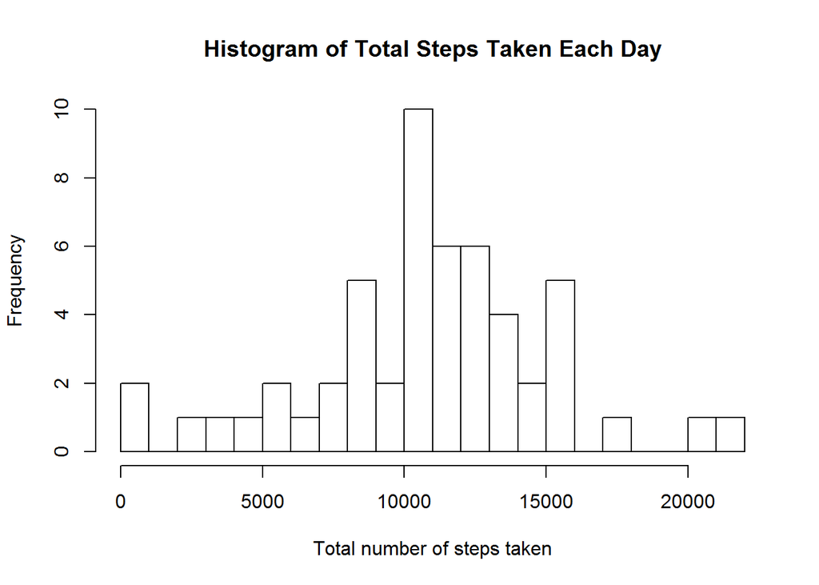

```r
hist(totalStepsData, breaks=20, xlab="Total number of steps taken",
     main="Histogram of Total Steps Taken Each Day")
```

The **mean** and **median** of the total number of steps taken per day can be calculated with the R summary() function:

```r
summary(totalStepsData)
```

```
##    Min. 1st Qu.  Median    Mean 3rd Qu.    Max.
##      41    8840   10800   10800   13300   21200
```

The mean is sometimes referred to as the average number, and the median is the number between the minimum and maximum values of the quantile.

## What is the average daily activity pattern?